# Diabetes Data Analysis

Zekarias Mengiste

2025-02-21

## Introduction

This analysis explores a publicly available diabetes dataset from Kaggle, containing demographic and medical features such as glucose levels, blood pressure, BMI, and insulin levels. The primary objective is to summarize key numerical variables: Glucose level, BMI, Age, and Pregnancies. Loading the Data

```
##   Pregnancies Glucose BloodPressure SkinThickness Insulin  BMI
## 1           6     148            72            35       0 33.6
## 2           1      85            66            29       0 26.6
## 3           8     183            64             0       0 23.3
## 4           1      89            66            23      94 28.1
## 5           0     137            40            35     168 43.1
## 6           5     116            74             0       0 25.6
##   DiabetesPedigreeFunction Age Outcome
## 1                    0.627  50       1
## 2                    0.351  31       0
## 3                    0.672  32       1
## 4                    0.167  21       0
## 5                    2.288  33       1
## 6                    0.201  30       0
```

## Summary of Descriptive Statistics

The table below presents descriptive statistics for Age, BMI, Glucose, and Pregnancies in the dataset.

Descriptive Statistics of Key Variables

| Variable | Age | BMI | Glucose | Pregnancies |
| --- | --- | --- | --- | --- |
| Max | 81.00000 | 67.10000 | 199.00000 | 17.000000 |
| Mean | 33.24089 | 31.99258 | 120.89453 | 3.845052 |
| Median | 29.00000 | 32.00000 | 117.00000 | 3.000000 |
| Min | 21.00000 | 0.00000 | 0.00000 | 0.000000 |
| SD | 11.76023 | 7.88416 | 31.97262 | 3.369578 |

### Table description (Key findings):

Age: Ranges from 21 to 81 years, with a mean of 33.24. BMI: Varies from 0 to 67.1, with a mean of 31.99 (BMI of 0 may indicate missing data). Glucose: Spans from 0 to 199, with a mean of 120.89, showing considerable variation. Pregnancies: Ranges from 0 to 17, with a mean of 3.85.

# Distribution of Blood Glucose Levels

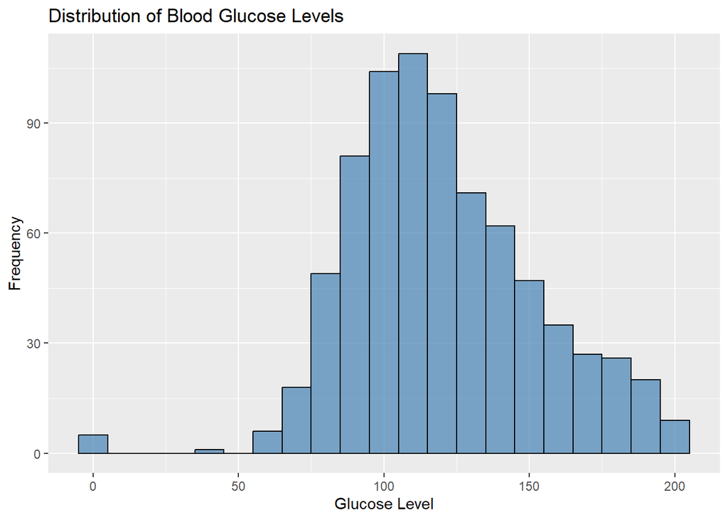

### Description of figure

The above histogram shows the distribution of blood glucose levels among participants in the study. The data appears to follow a roughly normal distribution, with most values concentrated between 80 and 150. There is a peak around 100-120, indicating that many individuals have glucose levels in this range.The distribution is slightly right-skewed, with some individuals having higher glucose levels up to 200.